# Heart Disease Mean Imputation

Esteban Salazar

2024-09-10

# Heart Disease Data Mean Imputation

During data cleaning we encounter missing or NA values. We can replace the numerical values with the average of each respective feature. For the categorical, we have to remove the values.

## Loading the data

```r
disease <- read.csv("C:/Users/esteb/iCloudDrive/Downloads/heartdisease1 copy.csv")
attach(disease)
```

The UCI Machine Learning Repository provides us with the following:

- 1(age), 4(trestbps), 5(chol), 8(thalach), 10(oldpeak), and 12(ca) are numerical
- 3(cp), 7(restecg), 11(slope), 13(thal) are categorical
- 2(sex), 6(fbs), 9(exang), and 14(heart disease) are binary

We can see that we have 303 total observations, however in mean imputation we will impute the numerical values and remove the categorical. This means we will have a smaller data set.

```r
# Numerical
disease$age[is.na(disease$age)] <- mean(disease$age,na.rm=TRUE) # 1
disease$trestbps[is.na(disease$trestbps)] <- mean(disease$trestbps,na.rm=TRUE) # 4
disease$chol[is.na(disease$chol)] <- mean(disease$chol,na.rm=TRUE) # 5
disease$thalach[is.na(disease$thalach)] <- mean(disease$thalach,na.rm=TRUE) # 8
disease$oldpeak[is.na(disease$oldpeak)] <- mean(disease$oldpeak,na.rm=TRUE) # 10
disease$ca[is.na(disease$ca)] <- round(mean(disease$ca,na.rm=TRUE), digits = 0) #12
```

```r
# Omit the Missing Values
dim(na.omit(disease))
```

```
## [1] 186  14
```

```r
disease <- na.omit(disease)
```

Now the size is significantly smaller 186

```r
# Categorical OR Binary
disease[,3] <- as.factor(disease[,3])
disease[,7] <- as.factor(disease[,7])
disease[,11] <- as.factor(disease[,11])
disease[,13] <- as.factor(disease[,13])
disease[,2] <- as.factor(disease[,2])
disease[,6] <- as.factor(disease[,6])
disease[,9] <- as.factor(disease[,9])
disease[,14] <- as.factor(disease[,14])
```

```r
levels(disease[,3]) # 4 Levels (1-4)
```

```
## [1] "1" "2" "3" "4"
```

```r
levels(disease[,7]) # 3 Levels (0-3)
```

```
## [1] "0" "1" "2"
```

```r
levels(disease[,11]) # 3 Levels (1-3)
```

```
## [1] "1" "2" "3"
```

```r
levels(disease[,13]) # 3 Levels (3, 6, 7)
```

```
## [1] "3" "6" "7"
```

```r
levels(disease[,2]) # 2 Levels 0 or 1
```

```
## [1] "0" "1"
```

```r
levels(disease[,6]) # 2 Levels 0 or 1
```

```
## [1] "0" "1"
```

```r
levels(disease[,9]) # 2 Levels 0 or 1
```

```
## [1] "0" "1"
```

## Exploratory Data Analysis

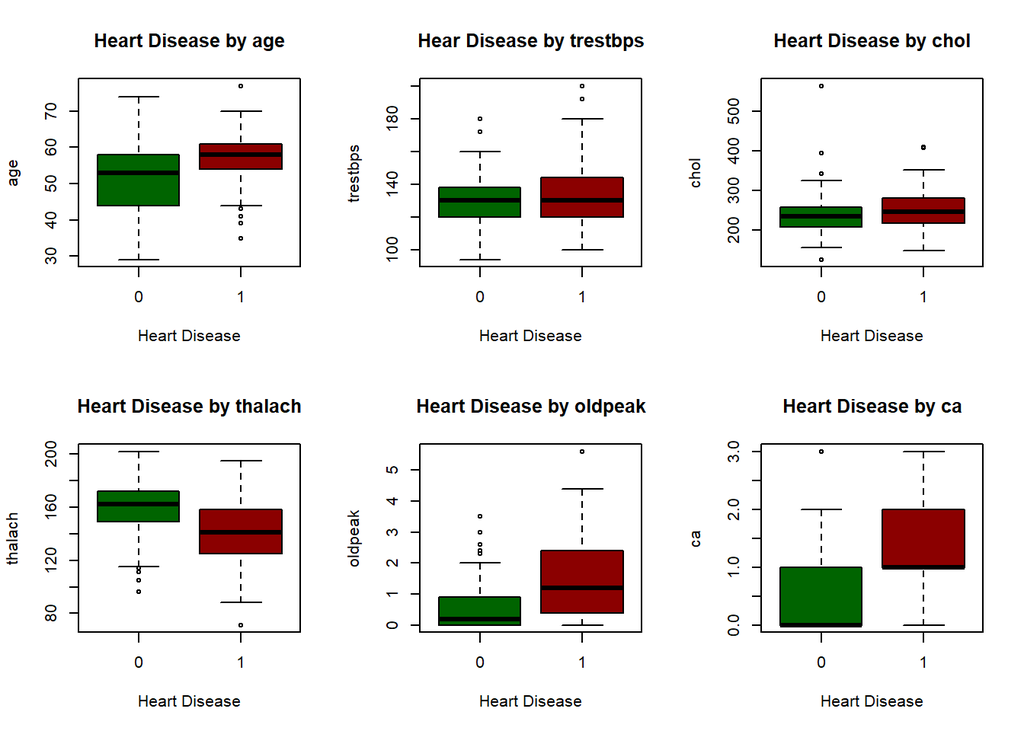

```r
par(mfrow = c(2,3))
xlabel = "Heart Disease"
boxplot(age~heartdisease, data = disease, col = c("darkgreen", "darkred"), main = "Heart Disease by age", xlab = xlabel)
boxplot(trestbps~heartdisease, data = disease, col = c("darkgreen", "darkred"), main = "Hear Disease by trestbps", xlab = xlabel) # Kinda different
boxplot(chol~heartdisease, data = disease, col = c("darkgreen", "darkred"), main = "Heart Disease by chol", xlab = xlabel) # Not very different
boxplot(thalach~heartdisease, data = disease, col = c("darkgreen", "darkred"), main = "Heart Disease by thalach", xlab = xlabel)
boxplot(oldpeak~heartdisease, data = disease, col = c("darkgreen", "darkred"), main = "Heart Disease by oldpeak", xlab = xlabel)
boxplot(ca~heartdisease, data = disease, col = c("darkgreen", "darkred"), main = "Heart Disease by ca", xlab = xlabel)
```

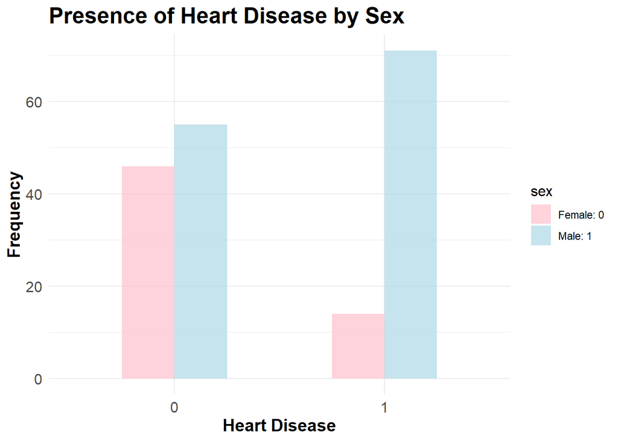

```r
# Barplot by Sex
colors = c('pink', 'lightblue')
ggplot(disease, aes(x=heartdisease, fill = sex)) +
  geom_bar(position = 'dodge', width = 0.5, alpha = 0.7) +
  scale_fill_manual(label = c("Female: 0", "Male: 1"),values=colors) +
  labs(x= 'Heart Disease', y= "Frequency") +
  ggtitle("Presence of Heart Disease by Sex") +
  theme_minimal() +
  theme(
    plot.title = element_text(size=18, face='bold'),
    axis.text = element_text(size=12),
    axis.title = element_text(size=14, face='bold'),
    legend.title = element_text(size=12)
  )
```

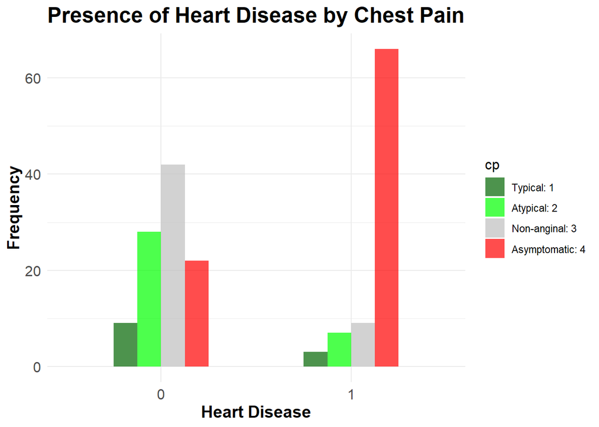

```r
# Barplot by Chest Pain cp
colors = c('darkgreen', 'green', 'grey', 'red')
ggplot(disease, aes(x=heartdisease, fill = cp)) +
  geom_bar(position = 'dodge', width = 0.5, alpha = 0.7) +
  scale_fill_manual(label = c("Typical: 1", "Atypical: 2", "Non-anginal: 3", "Asymptomatic: 4"),values=colors) +
  labs(x= 'Heart Disease', y= "Frequency") +
  ggtitle("Presence of Heart Disease by Chest Pain") +
  theme_minimal() +
  theme(
    plot.title = element_text(size=18, face='bold'),
    axis.text = element_text(size=12),
    axis.title = element_text(size=14, face='bold'),
    legend.title = element_text(size=12)
  )
```

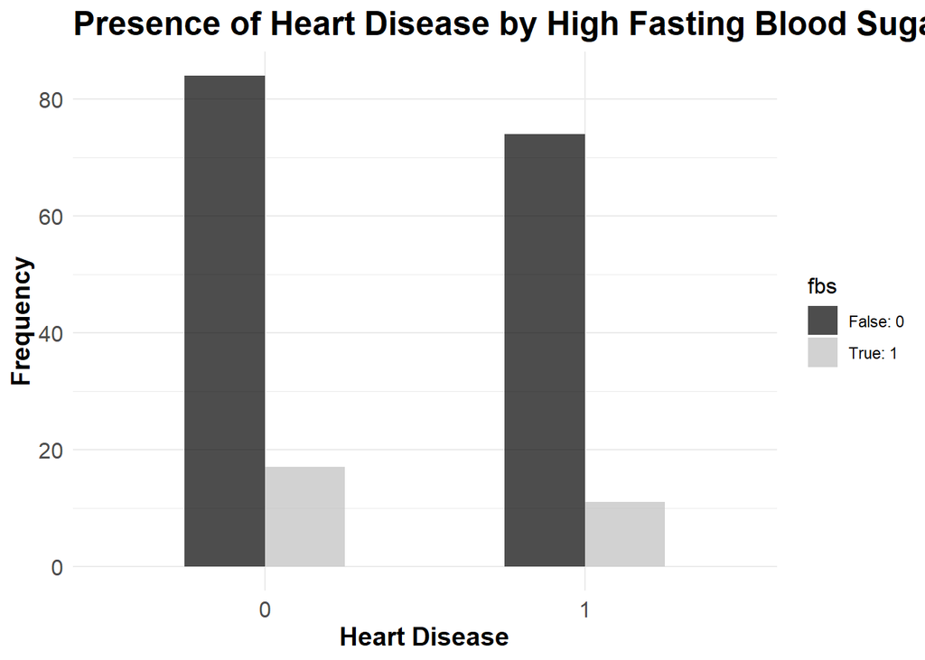

```r
colors = c('black', 'grey')
ggplot(disease, aes(x=heartdisease, fill = fbs)) +
  geom_bar(position = 'dodge', width = 0.5, alpha = 0.7) +
  scale_fill_manual(label = c("False: 0", "True: 1"),values=colors) +
  labs(x= 'Heart Disease', y= "Frequency") +
  ggtitle("Presence of Heart Disease by High Fasting Blood Sugar") +
  theme_minimal() +
  theme(
    plot.title = element_text(size=18, face='bold'),
    axis.text = element_text(size=12),
    axis.title = element_text(size=14, face='bold'),
    legend.title = element_text(size=12)
  )
```

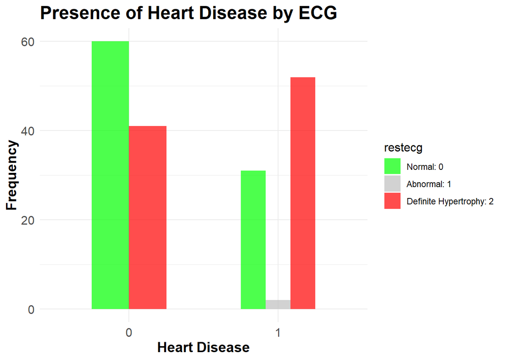

```r
colors = c('green', 'grey', 'red')
ggplot(disease, aes(x=heartdisease, fill = restecg)) +
  geom_bar(position = 'dodge', width = 0.5, alpha = 0.7) +
  scale_fill_manual(label = c("Normal: 0", "Abnormal: 1", "Definite Hypertrophy: 2"),values=colors) +
  labs(x= 'Heart Disease', y= "Frequency") +
  ggtitle("Presence of Heart Disease by ECG") +
  theme_minimal() +
  theme(
    plot.title = element_text(size=18, face='bold'),
    axis.text = element_text(size=12),
    axis.title = element_text(size=14, face='bold'),
    legend.title = element_text(size=12)
  )
```

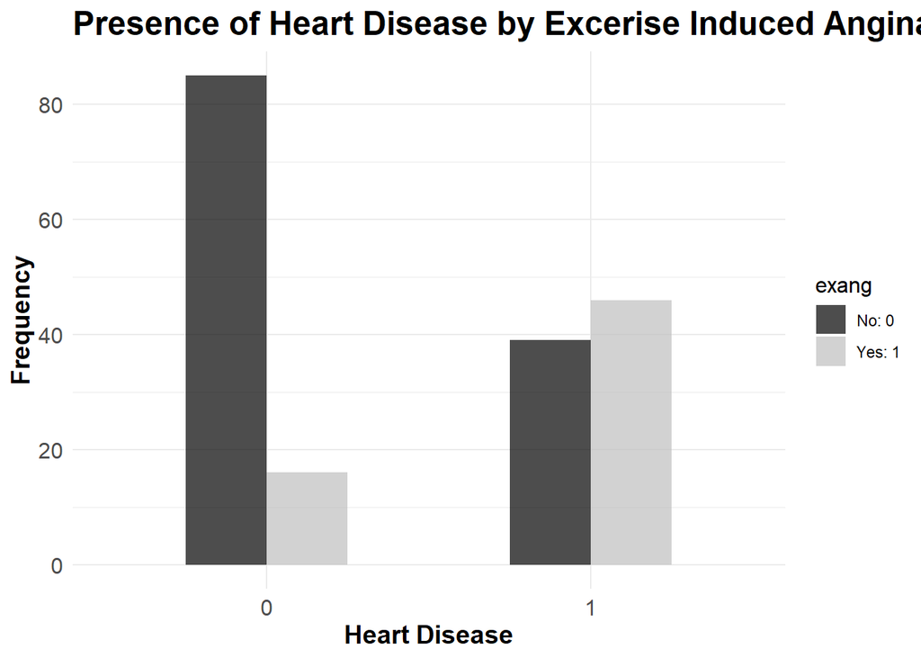

```r
colors = c('black','grey')
ggplot(disease, aes(x=heartdisease, fill = exang)) +
  geom_bar(position = 'dodge', width = 0.5, alpha = 0.7) +
  scale_fill_manual(label = c("No: 0", "Yes: 1"),values=colors) +
  labs(x= 'Heart Disease', y= "Frequency") +
  ggtitle("Presence of Heart Disease by Excerise Induced Angina") +
  theme_minimal() +
  theme(
    plot.title = element_text(size=18, face='bold'),
    axis.text = element_text(size=12),
    axis.title = element_text(size=14, face='bold'),
    legend.title = element_text(size=12)
  )
```

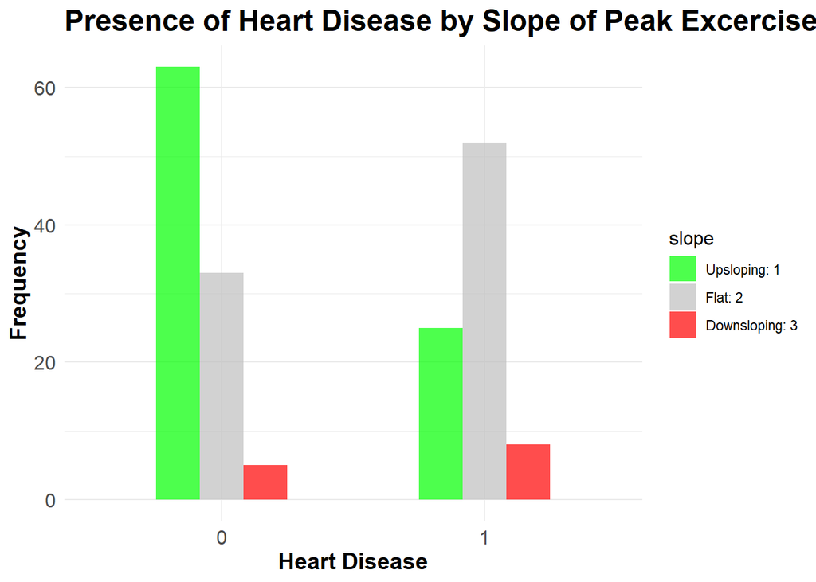

```r
colors = c('green', 'grey', 'red')
ggplot(disease, aes(x=heartdisease, fill = slope)) +
  geom_bar(position = 'dodge', width = 0.5, alpha = 0.7) +
  scale_fill_manual(label = c("Upsloping: 1", "Flat: 2", "Downsloping: 3"),values=colors) +
  labs(x= 'Heart Disease', y= "Frequency") +
  ggtitle("Presence of Heart Disease by Slope of Peak Excercise") +
  theme_minimal() +
  theme(
    plot.title = element_text(size=18, face='bold'),
    axis.text = element_text(size=12),
    axis.title = element_text(size=14, face='bold'),
    legend.title = element_text(size=12)
  )
```

[figure not shown]

```r
colors = c('green', 'grey', 'red')
ggplot(disease, aes(x=heartdisease, fill = thal)) +
  geom_bar(position = 'dodge', width = 0.5, alpha = 0.7) +
  scale_fill_manual(label = c("Normal: 3", "Fixed Defect: 6", "Reversable Defect: 7"),values=colors) +
  labs(x= 'Heart Disease', y= "Frequency") +
  ggtitle("Presence of Heart Disease by Chest Pain") +
  theme_minimal() +
  theme(
    plot.title = element_text(size=18, face='bold'),
    axis.text = element_text(size=12),
    axis.title = element_text(size=14, face='bold'),
    legend.title = element_text(size=12)
  )
```

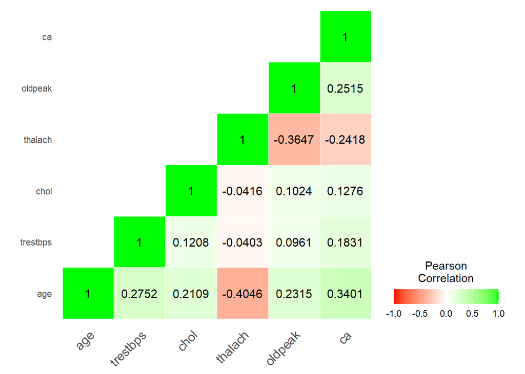

```r
# Correlation Matrix
cormat <- round(cor(disease[,-c(2,3,6,7,9,11,13, 14)]),4)

# Remove the redundant data from lower triangle
upper_tri <- function(cormat){
  cormat[lower.tri(cormat)] <- NA
  return(cormat)
}

# Making the heatmap
upper_triangle <- upper_tri(cormat)
library(reshape2)
melted_cormat <- melt(upper_triangle, na.rm = TRUE)
heatmap <- ggplot(melted_cormat, aes(Var2, Var1, fill=value)) +
  geom_tile(color="white")+
  scale_fill_gradient2(low = 'red', high = 'green', mid='white',
    midpoint = 0, limit=c(-1,1), space = 'Lab', name = "Pearson\nCorrelation") +
  theme_minimal()+
  theme(axis.text.x = element_text(angle=45, vjust=1, size=12, hjust = 1))+
  coord_fixed()

# Adding the correlation coefficients
heatmap +
geom_text(aes(Var2, Var1, label = value), color = "black", size = 4) +
theme(
  axis.title.x = element_blank(),
  axis.title.y = element_blank(),
  panel.grid.major = element_blank(),
  panel.border = element_blank(),
  panel.background = element_blank(),
  axis.ticks = element_blank(),
  legend.justification = c(1, 0),
  legend.position.inside = c(0.6, 0.7),
  legend.direction = "horizontal")+
  guides(fill = guide_colorbar(barwidth = 7, barheight = 1,
                title.position = "top", title.hjust = 0.5))
```

Most of these do not show very strong correlations with one another, but maybe several pairs would be worth looking into.

## Data Modeling

Now split the data into training and testing sets, using a 70-30 split.

```r
set.seed(2024)
samp <- sample(c(TRUE, FALSE), nrow(disease), replace = TRUE, prob = c(0.7,0.3))

train <- disease[samp,]
test <- disease[!samp,]
```

### Logistic Regression

```r
set.seed(2024)
# Build the model
log.model <- glm(heartdisease~., data = train, family = binomial)
```

```r
MASS::stepAIC(log.model, direction = "backward")
```

```
## Start:  AIC=117.62
## heartdisease ~ age + sex + cp + trestbps + chol + fbs + restecg +
##     thalach + exang + oldpeak + slope + ca + thal
##
##            Df Deviance    AIC
## - thal      2   81.544 115.54
## - thalach   1   79.624 115.62
## - chol      1   79.666 115.67
## - oldpeak   1   79.746 115.75
## - exang     1   79.842 115.84
## - slope     2   82.525 116.53
## <none>          79.623 117.62
## - trestbps  1   81.719 117.72
## - age       1   81.880 117.88
## - fbs       1   83.095 119.09
## - cp        3   88.779 120.78
## - restecg   2   87.333 121.33
## - sex       1   88.608 124.61
## - ca        1   88.708 124.71
##
## Step:  AIC=115.54
## heartdisease ~ age + sex + cp + trestbps + chol + fbs + restecg +
##     thalach + exang + oldpeak + slope + ca
##
##            Df Deviance    AIC
## - thalach   1   81.546 113.55
## - oldpeak   1   81.564 113.56
## - chol      1   81.745 113.75
## - exang     1   82.144 114.14
## - slope     2   85.402 115.40
## - trestbps  1   83.438 115.44
## <none>          81.544 115.54
## - age       1   84.440 116.44
## - fbs       1   84.984 116.98
## - cp        3   91.902 119.90
## - restecg   2   90.544 120.54
## - ca        1   93.277 125.28
## - sex       1   99.446 131.45
##
## Step:  AIC=113.55
```

[output cut: 49 more lines]

```
##
## Step:  AIC=108.54
## heartdisease ~ age + sex + cp + trestbps + fbs + restecg + slope +
##     ca
##
##            Df Deviance    AIC
## <none>          82.535 108.53
## - trestbps  1   85.456 109.46
## - fbs       1   86.002 110.00
## - age       1   86.488 110.49
## - slope     2   89.621 111.62
## - restecg   2   92.510 114.51
## - ca        1   97.234 121.23
## - cp        3  101.930 121.93
## - sex       1  102.849 126.85
```

```
##
## Call:  glm(formula = heartdisease ~ age + sex + cp + trestbps + fbs +
##     restecg + slope + ca, family = binomial, data = train)
##
## Coefficients:
## (Intercept)          age         sex1          cp2          cp3          cp4
##   -13.71088      0.07740      3.11328      0.04458     -0.23621      2.30928
##    trestbps         fbs1     restecg1     restecg2       slope2       slope3
##     0.02981     -1.99570     16.91847      1.69206      0.39782      3.38732
##          ca
##     1.38307
##
## Degrees of Freedom: 129 Total (i.e. Null);  117 Residual
## Null Deviance:       179.4
## Residual Deviance: 82.54     AIC: 108.5
```

```r
# Final model
log.model <- glm(heartdisease~age+sex+cp+trestbps+fbs+restecg+slope+ca, data = train, family = binomial)
```

```r
# Predicted probability of being in class
log.pred <- predict(log.model, newdata = test, type = "response")
log.class <- as.numeric(log.pred > 0.5)
# Confusion Matrix
(mat <- xtabs(~log.class + test$heartdisease))
```

```
##          test$heartdisease
## log.class  0  1
##         0 27  6
##         1  4 19
```

```r
# Error rate
(mat[1,2] + mat[2,1])/sum(mat)
```

```
## [1] 0.1785714
```

A error rate of about 0.1786

### ROC curve and AUC

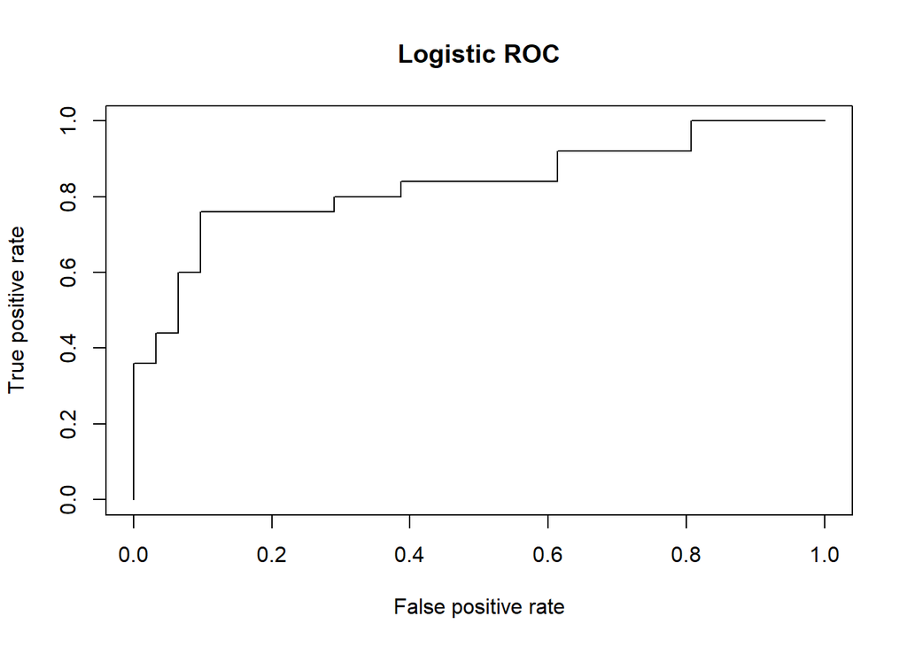

```r
set.seed(1)
log.pred <- predict(log.model, newdata = test)
pred <- prediction(predictions = log.pred, labels = test$heartdisease)

log.roc <- performance(pred, measure = "tpr", x.measure = "fpr")
plot(log.roc, main = "Logistic ROC")
```

```r
log_perf2 <- performance(pred, measure = "auc")
log_perf2@y.values[[1]]
```

```
## [1] 0.8309677
```

The AUC is about 0.8310.

### Random Forest

```r
p <- ncol(train) - 1
k <- 5
ntree <- c(100, 200, 300, 400, 500, 600, 700, 800, 900, 1000)

n <- 1:p
tuningpar <- expand.grid(n, ntree)
cv.er.forest <- matrix(nrow = k, ncol = nrow(tuningpar))
```

### Cross Validation K-Fold Split

```r
set.seed(1)
obs.per.fold <- ceiling(nrow(train)/k)
shuffle.indices <- sample(nrow(train), nrow(train))
folds <- vector("list", length = k)
for (i in 1:k) {
  if (i != k) {
    fold.indices <- (i - 1)*obs.per.fold + 1:obs.per.fold
    folds[[i]] <- shuffle.indices[fold.indices]
  } else {
    fold.indices <- ((i - 1)*obs.per.fold + 1):nrow(train)
    folds[[i]] <- shuffle.indices[fold.indices]
  }
}
```

### Testing for the two hyper parameters, ntrees && mtry.

```r
set.seed(1)
for (i in 1:k) {
  cv.training <- train[-folds[[i]],]
  cv.validation <- train[folds[[i]],]
    for (j in 1:nrow(tuningpar)) {
      rf <- randomForest(x = cv.training[,-14], y = cv.training[,14], mtry = tuningpar[j,1],
      ntree = tuningpar[j,2])
      rfpred <- predict(rf, newdata = cv.validation[,-14])
      cv.er.forest[i,j] <- mean(rfpred != cv.validation[,14])
    }
}
meancv <- colMeans(cv.er.forest)
optimal <- tuningpar[which(meancv == min(meancv)),]
names(optimal) <- c("# of Parameters", "# of Trees")
optimal
```

```
##    # of Parameters # of Trees
## 24              11        200
```

Found that 200 trees and 11 mtry parameters optimizes the randomforest model.

### Prediction based on the test case

```r
rand.forest <- randomForest(x = train[,-14], y = train[,14], mtry = 11, ntree = 200)

#Predicted probability of being in class
rand.pred <- predict(rand.forest, newdata = test[,-14], type = "prob")[,2]
```

### Importance

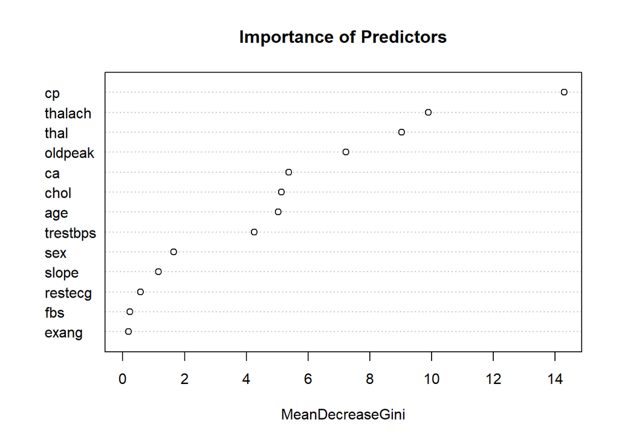

```r
varImpPlot(rand.forest, main = "Importance of Predictors")
```

We can see that by the gini index, the cp has the highest importance, followed by thalach then thal

### Random Forest Confusion Matrix

```r
rand.class <- predict(rand.forest, newdata = test[,-14], type = "response")
(mat <- xtabs(~rand.class + test$heartdisease))
```

```
##           test$heartdisease
## rand.class  0  1
##          0 25  7
##          1  6 18
```

```r
(mat[1,2]+mat[2,1])/sum(mat) # Error rate
```

```
## [1] 0.2321429
```

The test error rate is about 23.21%

### ROC and AUC Curves

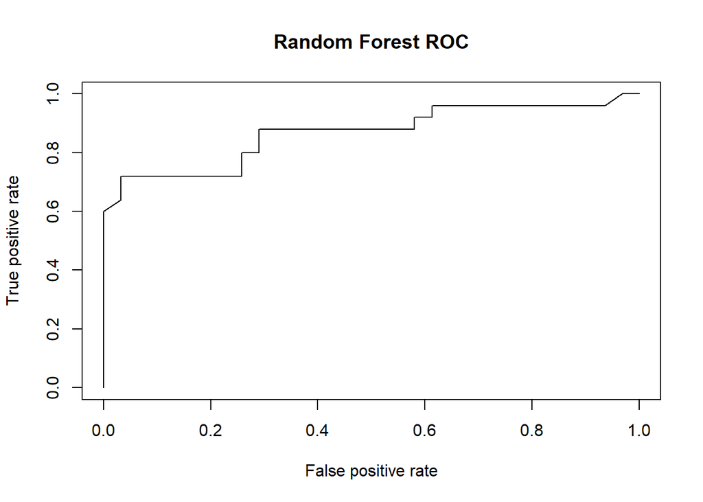

```r
set.seed(1)
pred <- prediction(predictions = rand.pred, labels = test$heartdisease)

rand.roc <- performance(pred, measure = "tpr", x.measure = "fpr")
plot(rand.roc, main = "Random Forest ROC")
```

```r
log_perf2 <- performance(pred, measure = "auc")
log_perf2@y.values[[1]]
```

```
## [1] 0.8670968
```

The area under the curve is about 86.71%

### Chosen Method) SVM

```r
set.seed(2024)
tune.out <- tune(svm, heartdisease~., data = train, kernel = "polynomial",ranges = list(cost = c(0.001, 0.01, 0.1, 1, 10, 100), degree = c(1,2,3,4)))
summary(tune.out)
```

```
##
## Parameter tuning of 'svm':
##
## - sampling method: 10-fold cross validation
##
## - best parameters:
##  cost degree
##     1      1
##
## - best performance: 0.1769231
##
## - Detailed performance results:
##     cost degree     error dispersion
## 1  1e-03      1 0.4615385 0.10878566
## 2  1e-02      1 0.4615385 0.10878566
## 3  1e-01      1 0.2307692 0.09593993
## 4  1e+00      1 0.1769231 0.12587628
## 5  1e+01      1 0.2000000 0.13664526
## 6  1e+02      1 0.2000000 0.11581118
## 7  1e-03      2 0.4615385 0.10878566
## 8  1e-02      2 0.4615385 0.10878566
## 9  1e-01      2 0.4615385 0.10878566
## 10 1e+00      2 0.2230769 0.09209377
## 11 1e+01      2 0.2000000 0.09029137
## 12 1e+02      2 0.2923077 0.11351766
## 13 1e-03      3 0.4615385 0.10878566
## 14 1e-02      3 0.4615385 0.10878566
## 15 1e-01      3 0.4615385 0.10878566
## 16 1e+00      3 0.3153846 0.05675883
## 17 1e+01      3 0.2461538 0.08733019
## 18 1e+02      3 0.2846154 0.08919245
## 19 1e-03      4 0.4615385 0.10878566
## 20 1e-02      4 0.4615385 0.10878566
## 21 1e-01      4 0.4615385 0.10878566
## 22 1e+00      4 0.3846154 0.10256410
## 23 1e+01      4 0.2923077 0.08733019
## 24 1e+02      4 0.2769231 0.11581118
```

```r
best <- summary(tune.out)$best.model
```

```r
svm.pred <- predict(best, newdata = test)
(mat <- xtabs(~svm.pred + test$heartdisease))
```

```
##         test$heartdisease
## svm.pred  0  1
##        0 30  6
##        1  1 19
```

```r
(mat[1,2] + mat[2,1])/sum(mat)
```

```
## [1] 0.125
```

About 12.50%

### ROC

```r
#Create the function
rocplot<-function(predi,truth,...){
predob<-prediction(predi,truth)
perf<-performance(predob,"tpr","fpr")
plot(perf,...)
}
```

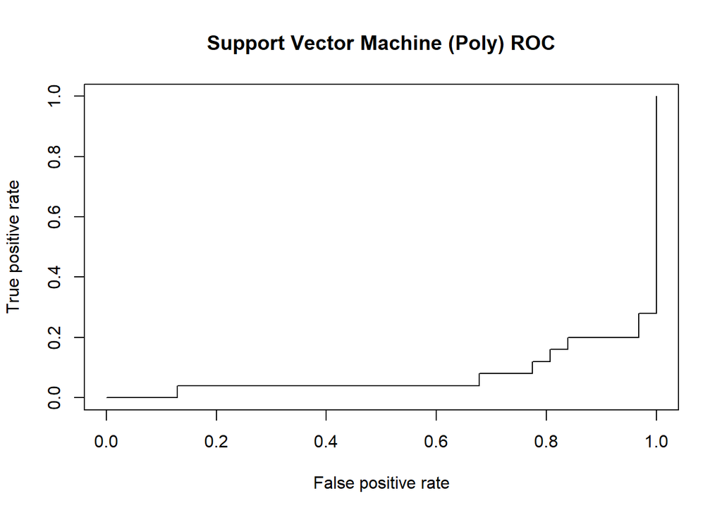

```r
# Obtain the fitted values
svm.fit <- svm(heartdisease~., data = train, kernel = "polynomial", degree = 1, cost = 1, decision.values=TRUE)
fitted <- attributes(predict(svm.fit, newdata = test, decision.values=TRUE))$decision.values
rocplot(-fitted, test$heartdisease, main = "Support Vector Machine (Poly) ROC")
```

### AUC

```r
svm.fit <- svm(heartdisease~., data = train, kernel = "polynomial", degree = 1, cost = 1, probability=TRUE)
prob <- attributes(predict(svm.fit, newdata = test, probability =TRUE))$probabilities[,2]

predictionsvm <- prediction(prob,test$heartdisease)
svm_perf2 <- performance(predictionsvm, measure = "auc")
svm_perf2@y.values[[1]]
```

```
## [1] 0.07354839
```